# Asociacion y depuracion de variables cuantitativas (Etapa 4)

Edwin Silva Salas & Edwin Henao Ochoa

2026-08-22

# Etapa 4 — Asociacion y depuracion de variables cuantitativas

Dataset de entrada: **$D_{\mathrm{mod}}$** (`data_agrupada_mod.csv`, cuadrante × semana, 2024–2025).

Este informe operacionaliza la depuracion cuantitativa de la Etapa 4. A diferencia del EDA (Secciones 5.3.7 y 5.3.8, informes `analisis_correlacion.html` y `analisis_multivariado.html`), que caracteriza asociaciones sobre las variables *tal como fueron observadas*, aqui se evalua el **conjunto candidato de predictoras *ex ante***: solo variables cuyo valor esta disponible antes del inicio de la semana $t$ que se pronostica.

Criterio rector: evitar **fuga de informacion**. Por construccion se excluyen del conjunto candidato las variables contemporaneas de impacto posterior (`usuarios_afectados`$_t$, `elementos_afectados`$_t$) y la respuesta alterna contemporanea. La depuracion **no elimina filas ni columnas de $D_{\mathrm{mod}}$**: descarta variables de la matriz de diseño y deja constancia del motivo.

Secuencia aplicada:

1. Construccion del conjunto candidato *ex ante* (clima rezagado, historico de eventos, rasgos del cuadrante, exposicion y estacionalidad).
2. Filtro de varianza casi nula y de cobertura.
3. Asociacion monotona (Spearman) con `SAIFI` y `SAIDI`, con correccion FDR.
4. Depuracion por redundancia (agrupamiento por $1-|\rho|$) y por multicolinealidad (VIF iterativo).
5. Bitacora de decisiones y exportacion de la matriz de diseño depurada.

Todas las decisiones se toman **solo con el conjunto de entrenamiento (2024)**; 2025 se reserva para la prueba final y no interviene en la seleccion de variables.

```r
library(tidyverse)
library(lubridate)
library(scales)
library(knitr)
```

```r
env_path <- file.path("..", "..", ".env")
if (file.exists(".env")) {
  readRenviron(".env")
} else if (file.exists(env_path)) {
  readRenviron(env_path)
}

UBICACION_DATA <- Sys.getenv("UBICACION_DATA")
if (UBICACION_DATA == "") {
  stop("UBICACION_DATA no esta definida. Verifica el archivo .env.")
}

path_mod <- file.path(UBICACION_DATA, "data_agrupada_mod.csv")
if (!file.exists(path_mod)) {
  stop("No se encontro: ", path_mod)
}

path_elementos <- file.path(
  UBICACION_DATA, "Distribución de Cuadrantes", "ELEMENTO_FALLA_CUADRANTE_800.xls"
)

path_salida_datos <- file.path(UBICACION_DATA, "data_modelado_cuanti.csv")
path_salida_bitacora <- file.path(UBICACION_DATA, "decision_variables_cuanti.csv")

path_img_tesis <- file.path("..", "my-paper-overleaf", "img")

ANIO_TRAIN <- 2024
ANIO_TEST <- 2025
UMBRAL_RHO_REDUNDANTE <- 0.70
UMBRAL_VIF <- 5
UMBRAL_ALPHA_FDR <- 0.05
```

```r
guardar_plot <- function(plot, archivo, width, height) {
  ggsave(
    file.path(UBICACION_DATA, archivo),
    plot = plot,
    width = width,
    height = height,
    dpi = 300,
    bg = "white"
  )
  if (dir.exists(path_img_tesis)) {
    file.copy(
      file.path(UBICACION_DATA, archivo),
      file.path(path_img_tesis, archivo),
      overwrite = TRUE
    )
  }
}
```

```r
d_mod <- read_csv(path_mod, show_col_types = FALSE)

if (!inherits(d_mod$semana, "Date")) {
  d_mod <- d_mod %>% mutate(semana = as.Date(semana))
}

# Si D_mod aun no trae UT mensual, se reasigna desde data_usuarios_totales_sistema.csv
# por mes calendario de la semana.
path_ut <- file.path(UBICACION_DATA, "data_usuarios_totales_sistema.csv")
necesita_ut <- !all(c("usuarios_totales", "SAIFI", "SAIDI") %in% names(d_mod)) ||
  (n_distinct(d_mod$usuarios_totales) <= 1)

if (necesita_ut) {
  if (!file.exists(path_ut)) {
    stop("No se encontro: ", path_ut)
  }
  ut_mensual <- read_csv(path_ut, show_col_types = FALSE) %>%
    rename(periodo_op = CS1_PERIODO_OP, usuarios_totales = CS1_UT_M) %>%
    mutate(
      periodo_op = as.Date(periodo_op, format = "%d/%m/%y"),
      anio_mes = floor_date(periodo_op, "month")
    ) %>%
    select(anio_mes, usuarios_totales) %>%
    distinct(anio_mes, .keep_all = TRUE)

  d_mod <- d_mod %>%
    select(-any_of(c("usuarios_totales", "SAIFI", "SAIDI"))) %>%
    mutate(anio_mes = floor_date(semana, "month")) %>%
    left_join(ut_mensual, by = "anio_mes") %>%
    select(-anio_mes) %>%
    mutate(
      SAIFI = usuarios_afectados / usuarios_totales,
      SAIDI = (duracion_total * usuarios_afectados) / usuarios_totales
    )
}

if (any(is.na(d_mod$usuarios_totales))) {
  stop("Hay semanas sin UT mensual. Revisar data_usuarios_totales_sistema.csv.")
}

d_mod <- d_mod %>% arrange(id_cuadrante, semana)

resumen_panel <- tibble(
  metrica = c("Filas", "Cuadrantes", "Semanas", "Semana min", "Semana max", "Total eventos"),
  valor = c(
    format(nrow(d_mod), big.mark = ","),
    as.character(n_distinct(d_mod$id_cuadrante)),
    as.character(n_distinct(d_mod$semana)),
    as.character(min(d_mod$semana)),
    as.character(max(d_mod$semana)),
    format(sum(d_mod$n_eventos, na.rm = TRUE), big.mark = ",")
  )
)

kable(resumen_panel, col.names = c("Metrica", "Valor"),
      caption = "Panel de entrada D_mod")
```

Panel de entrada D_mod

| Metrica | Valor |
| --- | --- |
| Filas | 36,120 |
| Cuadrantes | 344 |
| Semanas | 105 |
| Semana min | 2024-01-01 |
| Semana max | 2025-12-29 |
| Total eventos | 33,410 |

## 1. Construccion del conjunto candidato *ex ante*

Rezagos y acumulados se calculan **dentro de cada cuadrante** sobre la serie semanal ordenada. La exposicion (`n_activos`) proviene del inventario de elementos por cuadrante y es constante en el tiempo; se incorpora en escala logaritmica como candidata a *offset*.

```r
exposicion <- NULL

if (file.exists(path_elementos) && requireNamespace("readxl", quietly = TRUE)) {
  exposicion <- readxl::read_excel(path_elementos) %>%
    select(ELEMENTO, CUADRANTE_1) %>%
    distinct() %>%
    rename(id_cuadrante = CUADRANTE_1) %>%
    filter(!is.na(id_cuadrante)) %>%
    count(id_cuadrante, name = "n_activos")
}

if (is.null(exposicion)) {
  warning("Inventario de elementos no disponible; se omite la exposicion n_activos.")
  d_base <- d_mod %>% mutate(n_activos = NA_real_)
} else {
  d_base <- d_mod %>%
    mutate(id_cuadrante = as.character(id_cuadrante)) %>%
    left_join(
      exposicion %>% mutate(id_cuadrante = as.character(id_cuadrante)),
      by = "id_cuadrante"
    )

  kable(
    tibble(
      metrica = c("Cuadrantes con exposicion", "Cuadrantes sin exposicion",
                  "Activos por cuadrante (mediana)", "Activos por cuadrante (max)"),
      valor = c(
        sum(!is.na(unique(d_base$n_activos))),
        n_distinct(d_base$id_cuadrante[is.na(d_base$n_activos)]),
        median(exposicion$n_activos),
        max(exposicion$n_activos)
      )
    ),
    col.names = c("Metrica", "Valor"),
    caption = "Exposicion por cuadrante (numero de activos del inventario)"
  )
}
```

Exposicion por cuadrante (numero de activos del inventario)

| Metrica | Valor |
| --- | --- |
| Cuadrantes con exposicion | 191 |
| Cuadrantes sin exposicion | 0 |
| Activos por cuadrante (mediana) | 94 |
| Activos por cuadrante (max) | 5276 |

```r
vars_clima <- c(
  "temp_media_semana", "temp_max_semana", "temp_min_semana",
  "humedad_media_semana", "viento_medio_semana", "viento_max_semana",
  "precip_total_semana"
)

d_feat <- d_base %>%
  group_by(id_cuadrante) %>%
  mutate(
    across(all_of(vars_clima), ~ lag(.x, 1), .names = "{.col}_lag1"),
    across(all_of(vars_clima), ~ lag(.x, 2), .names = "{.col}_lag2"),
    precip_acum4_lag = lag(precip_total_semana, 1) + lag(precip_total_semana, 2) +
      lag(precip_total_semana, 3) + lag(precip_total_semana, 4),
    eventos_lag1 = lag(n_eventos, 1),
    eventos_lag2 = lag(n_eventos, 2),
    eventos_lag3 = lag(n_eventos, 3),
    eventos_ma4_lag = (lag(n_eventos, 1) + lag(n_eventos, 2) +
      lag(n_eventos, 3) + lag(n_eventos, 4)) / 4,
    duracion_lag1 = lag(duracion_total, 1),
    duracion_ma4_lag = (lag(duracion_total, 1) + lag(duracion_total, 2) +
      lag(duracion_total, 3) + lag(duracion_total, 4)) / 4
  ) %>%
  ungroup() %>%
  mutate(
    anio = year(semana),
    semana_anio = isoweek(semana),
    estacion_sin = sin(2 * pi * semana_anio / 52),
    estacion_cos = cos(2 * pi * semana_anio / 52),
    log_activos = if (all(is.na(n_activos))) NA_real_ else log(n_activos + 1),
    particion = if_else(anio == ANIO_TRAIN, "entrenamiento", "prueba")
  )

vars_clima_lag <- c(paste0(vars_clima, "_lag1"), paste0(vars_clima, "_lag2"), "precip_acum4_lag")
vars_historico <- c("eventos_lag1", "eventos_lag2", "eventos_lag3", "eventos_ma4_lag",
                    "duracion_lag1", "duracion_ma4_lag")
vars_cuadrante <- c("altitud", "latitud", "longitud", "log_activos")
vars_estacion <- c("estacion_sin", "estacion_cos")

candidatas <- c(vars_clima_lag, vars_historico, vars_cuadrante, vars_estacion)
candidatas <- candidatas[candidatas %in% names(d_feat)]

grupo_candidata <- function(v) {
  case_when(
    v %in% vars_clima_lag ~ "Clima rezagado",
    v %in% vars_historico ~ "Historico de eventos",
    v %in% vars_cuadrante ~ "Rasgo del cuadrante / exposicion",
    v %in% vars_estacion ~ "Estacionalidad",
    TRUE ~ "Otro"
  )
}

kable(
  tibble(variable = candidatas, grupo = grupo_candidata(candidatas)) %>%
    count(grupo, name = "n_variables"),
  col.names = c("Grupo", "Numero de candidatas"),
  caption = "Conjunto candidato ex ante por grupo"
)
```

Conjunto candidato ex ante por grupo

| Grupo | Numero de candidatas |
| --- | --- |
| Clima rezagado | 15 |
| Estacionalidad | 2 |
| Historico de eventos | 6 |
| Rasgo del cuadrante / exposicion | 4 |

```r
excluidas_diseno <- tibble(
  variable = c("usuarios_afectados", "elementos_afectados",
               "SAIFI (contemporanea)", "SAIDI (contemporanea)",
               "n_eventos (contemporanea)", "duracion_total (contemporanea)",
               vars_clima),
  motivo = c(
    "Insumo de SAIFI/SAIDI; no disponible ex ante como predictora",
    "Impacto posterior: no disponible ex ante",
    "Variable respuesta contemporanea",
    "Variable respuesta contemporanea",
    "Insumo de construccion; no es la respuesta a predecir",
    "Insumo de construccion; no es la respuesta a predecir",
    rep("Clima contemporaneo: se sustituye por su version rezagada", length(vars_clima))
  )
)

kable(excluidas_diseno, col.names = c("Variable", "Motivo de exclusion"),
      caption = "Variables excluidas del conjunto candidato por diseño (previo a cualquier prueba)")
```

Variables excluidas del conjunto candidato por diseño (previo a cualquier prueba)

| Variable | Motivo de exclusion |
| --- | --- |
| usuarios_afectados | Insumo de SAIFI/SAIDI; no disponible ex ante como predictora |
| elementos_afectados | Impacto posterior: no disponible ex ante |
| SAIFI (contemporanea) | Variable respuesta contemporanea |
| SAIDI (contemporanea) | Variable respuesta contemporanea |
| n_eventos (contemporanea) | Insumo de construccion; no es la respuesta a predecir |
| duracion_total (contemporanea) | Insumo de construccion; no es la respuesta a predecir |
| temp_media_semana | Clima contemporaneo: se sustituye por su version rezagada |
| temp_max_semana | Clima contemporaneo: se sustituye por su version rezagada |
| temp_min_semana | Clima contemporaneo: se sustituye por su version rezagada |
| humedad_media_semana | Clima contemporaneo: se sustituye por su version rezagada |
| viento_medio_semana | Clima contemporaneo: se sustituye por su version rezagada |
| viento_max_semana | Clima contemporaneo: se sustituye por su version rezagada |
| precip_total_semana | Clima contemporaneo: se sustituye por su version rezagada |

## 2. Cobertura y varianza casi nula

Los rezagos generan valores faltantes en las primeras semanas de cada cuadrante (perdida esperada de cuatro semanas por cuadrante). Una candidata con cobertura inferior al 90 % se descarta antes de filtrar filas, para no perder cuadrantes completos por una sola variable (por ejemplo, cuadrantes sin correspondencia en el inventario de activos).

```r
UMBRAL_COBERTURA <- 0.90

cobertura <- d_feat %>%
  summarise(across(all_of(candidatas), ~ mean(!is.na(.x)))) %>%
  pivot_longer(everything(), names_to = "variable", values_to = "cobertura_prop") %>%
  mutate(
    grupo = grupo_candidata(variable),
    cobertura = round(100 * cobertura_prop, 2),
    suficiente = cobertura_prop >= UMBRAL_COBERTURA
  ) %>%
  arrange(cobertura)

kable(cobertura %>% slice_head(n = 10) %>% select(variable, cobertura, grupo, suficiente),
      col.names = c("Variable", "Cobertura (%)", "Grupo", "Cobertura suficiente"),
      caption = "Diez candidatas con menor cobertura")
```

Diez candidatas con menor cobertura

| Variable | Cobertura (%) | Grupo | Cobertura suficiente |
| --- | --- | --- | --- |
| precip_acum4_lag | 96.19 | Clima rezagado | TRUE |
| eventos_ma4_lag | 96.19 | Historico de eventos | TRUE |
| duracion_ma4_lag | 96.19 | Historico de eventos | TRUE |
| eventos_lag3 | 97.14 | Historico de eventos | TRUE |
| temp_media_semana_lag2 | 98.10 | Clima rezagado | TRUE |
| temp_max_semana_lag2 | 98.10 | Clima rezagado | TRUE |
| temp_min_semana_lag2 | 98.10 | Clima rezagado | TRUE |
| humedad_media_semana_lag2 | 98.10 | Clima rezagado | TRUE |
| viento_medio_semana_lag2 | 98.10 | Clima rezagado | TRUE |
| viento_max_semana_lag2 | 98.10 | Clima rezagado | TRUE |

```r
vars_cobertura_baja <- cobertura %>% filter(!suficiente) %>% pull(variable)
candidatas <- setdiff(candidatas, vars_cobertura_baja)

if (length(vars_cobertura_baja) > 0) {
  kable(
    cobertura %>%
      filter(variable %in% vars_cobertura_baja) %>%
      select(variable, grupo, cobertura),
    col.names = c("Variable", "Grupo", "Cobertura (%)"),
    caption = paste0("Candidatas descartadas por cobertura < ", UMBRAL_COBERTURA * 100, "%")
  )
}

d_completo <- d_feat %>% drop_na(all_of(candidatas))

d_train <- d_completo %>% filter(particion == "entrenamiento")
d_test <- d_completo %>% filter(particion == "prueba")

kable(
  tibble(
    conjunto = c("D_mod original", "Con candidatas completas",
                 paste0("Entrenamiento (", ANIO_TRAIN, ")"),
                 paste0("Prueba (", ANIO_TEST, ")")),
    filas = format(c(nrow(d_feat), nrow(d_completo), nrow(d_train), nrow(d_test)),
                   big.mark = ",")
  ),
  col.names = c("Conjunto", "Filas"),
  caption = "Efecto de los rezagos sobre el numero de filas utilizables"
)
```

Efecto de los rezagos sobre el numero de filas utilizables

| Conjunto | Filas |
| --- | --- |
| D_mod original | 36,120 |
| Con candidatas completas | 34,744 |
| Entrenamiento (2024) | 16,856 |
| Prueba (2025) | 17,888 |

```r
diagnostico_varianza <- tibble(variable = candidatas) %>%
  rowwise() %>%
  mutate(
    desv_est = sd(d_train[[variable]], na.rm = TRUE),
    frec_modal = max(table(d_train[[variable]])) / nrow(d_train),
    valores_unicos = n_distinct(d_train[[variable]])
  ) %>%
  ungroup() %>%
  mutate(
    varianza_casi_nula = desv_est == 0 | frec_modal > 0.99 | valores_unicos < 3
  )

vars_varianza_nula <- diagnostico_varianza %>%
  filter(varianza_casi_nula) %>%
  pull(variable)

kable(
  diagnostico_varianza %>%
    mutate(desv_est = signif(desv_est, 3), frec_modal = round(frec_modal, 3)) %>%
    select(variable, desv_est, frec_modal, valores_unicos, varianza_casi_nula) %>%
    arrange(desv_est),
  col.names = c("Variable", "Desv. est.", "Frec. modal", "Valores unicos", "Varianza casi nula"),
  caption = "Filtro de varianza casi nula (entrenamiento 2024)"
)
```

Filtro de varianza casi nula (entrenamiento 2024)

| Variable | Desv. est. | Frec. modal | Valores unicos | Varianza casi nula |
| --- | --- | --- | --- | --- |
| longitud | 0.407 | 0.003 | 344 | FALSE |
| latitud | 0.493 | 0.003 | 344 | FALSE |
| estacion_cos | 0.689 | 0.041 | 45 | FALSE |
| estacion_sin | 0.723 | 0.041 | 42 | FALSE |
| viento_medio_semana_lag1 | 0.775 | 0.009 | 3703 | FALSE |
| viento_medio_semana_lag2 | 0.782 | 0.009 | 3708 | FALSE |
| viento_max_semana_lag1 | 0.973 | 0.021 | 209 | FALSE |
| viento_max_semana_lag2 | 0.977 | 0.021 | 212 | FALSE |
| log_activos | 1.310 | 0.035 | 191 | FALSE |
| eventos_ma4_lag | 1.700 | 0.394 | 77 | FALSE |
| eventos_lag3 | 2.000 | 0.652 | 34 | FALSE |
| eventos_lag2 | 2.010 | 0.648 | 34 | FALSE |
| eventos_lag1 | 2.020 | 0.644 | 34 | FALSE |
| temp_min_semana_lag1 | 4.430 | 0.010 | 526 | FALSE |
| temp_min_semana_lag2 | 4.440 | 0.010 | 526 | FALSE |
| temp_media_semana_lag1 | 4.490 | 0.005 | 4038 | FALSE |
| temp_media_semana_lag2 | 4.510 | 0.005 | 4035 | FALSE |
| temp_max_semana_lag1 | 5.240 | 0.007 | 614 | FALSE |
| temp_max_semana_lag2 | 5.260 | 0.007 | 612 | FALSE |
| humedad_media_semana_lag1 | 11.100 | 0.003 | 4073 | FALSE |
| humedad_media_semana_lag2 | 11.300 | 0.003 | 4076 | FALSE |
| precip_total_semana_lag1 | 20.600 | 0.022 | 3956 | FALSE |
| precip_total_semana_lag2 | 20.700 | 0.042 | 3872 | FALSE |
| precip_acum4_lag | 51.100 | 0.005 | 4092 | FALSE |
| duracion_ma4_lag | 75.800 | 0.379 | 7254 | FALSE |
| duracion_lag1 | 86.800 | 0.602 | 4233 | FALSE |
| altitud | 862.000 | 0.015 | 298 | FALSE |

## 3. Asociacion con las variables respuesta

Se usa **Spearman** por la asimetria y exceso de ceros documentados en el EDA. Los $p$-valores se corrigen por comparaciones multiples con el procedimiento de Benjamini–Hochberg (FDR).

```r
spearman_vs <- function(data, variables, respuesta) {
  map_dfr(variables, function(v) {
    x <- data[[v]]
    y <- data[[respuesta]]
    ok <- complete.cases(x, y)
    if (sum(ok) < 3 || sd(x[ok]) == 0) {
      return(tibble(variable = v, rho = NA_real_, p_value = NA_real_))
    }
    ct <- suppressWarnings(
      cor.test(x[ok], y[ok], method = "spearman", exact = FALSE)
    )
    tibble(variable = v, rho = unname(ct$estimate), p_value = ct$p.value)
  }) %>%
    mutate(p_fdr = p.adjust(p_value, method = "BH"))
}

asoc_saifi <- spearman_vs(d_train, candidatas, "SAIFI") %>%
  rename(rho_saifi = rho, p_saifi = p_value, fdr_saifi = p_fdr)

asoc_saidi <- spearman_vs(d_train, candidatas, "SAIDI") %>%
  rename(rho_saidi = rho, p_saidi = p_value, fdr_saidi = p_fdr)

asociacion <- asoc_saifi %>%
  left_join(asoc_saidi, by = "variable") %>%
  mutate(
    grupo = grupo_candidata(variable),
    signif_alguna = (fdr_saifi < UMBRAL_ALPHA_FDR) | (fdr_saidi < UMBRAL_ALPHA_FDR)
  ) %>%
  arrange(desc(abs(rho_saifi)))

kable(
  asociacion %>%
    transmute(
      variable, grupo,
      rho_saifi = round(rho_saifi, 3),
      fdr_saifi = signif(fdr_saifi, 3),
      rho_saidi = round(rho_saidi, 3),
      fdr_saidi = signif(fdr_saidi, 3),
      signif_alguna = if_else(signif_alguna, "Si", "No")
    ),
  col.names = c("Variable", "Grupo", "rho (SAIFI)", "FDR", "rho (SAIDI)", "FDR",
                "Sig. FDR 5%"),
  caption = "Asociacion Spearman de las candidatas ex ante con SAIFI y SAIDI (entrenamiento 2024)"
)
```

Asociacion Spearman de las candidatas ex ante con SAIFI y SAIDI (entrenamiento 2024)

| Variable | Grupo | rho (SAIFI) | FDR | rho (SAIDI) | FDR | Sig. FDR 5% |
| --- | --- | --- | --- | --- | --- | --- |
| eventos_ma4_lag | Historico de eventos | 0.569 | 0.00e+00 | 0.576 | 0.00e+00 | Si |
| log_activos | Rasgo del cuadrante / exposicion | 0.508 | 0.00e+00 | 0.500 | 0.00e+00 | Si |
| eventos_lag1 | Historico de eventos | 0.482 | 0.00e+00 | 0.495 | 0.00e+00 | Si |
| eventos_lag2 | Historico de eventos | 0.457 | 0.00e+00 | 0.463 | 0.00e+00 | Si |
| duracion_ma4_lag | Historico de eventos | 0.451 | 0.00e+00 | 0.474 | 0.00e+00 | Si |
| eventos_lag3 | Historico de eventos | 0.440 | 0.00e+00 | 0.445 | 0.00e+00 | Si |
| duracion_lag1 | Historico de eventos | 0.416 | 0.00e+00 | 0.445 | 0.00e+00 | Si |
| estacion_sin | Estacionalidad | -0.151 | 0.00e+00 | -0.170 | 0.00e+00 | Si |
| longitud | Rasgo del cuadrante / exposicion | 0.146 | 0.00e+00 | 0.148 | 0.00e+00 | Si |
| viento_max_semana_lag2 | Clima rezagado | 0.116 | 0.00e+00 | 0.118 | 0.00e+00 | Si |
| viento_medio_semana_lag2 | Clima rezagado | 0.113 | 0.00e+00 | 0.114 | 0.00e+00 | Si |
| viento_max_semana_lag1 | Clima rezagado | 0.112 | 0.00e+00 | 0.113 | 0.00e+00 | Si |
| viento_medio_semana_lag1 | Clima rezagado | 0.112 | 0.00e+00 | 0.112 | 0.00e+00 | Si |
| estacion_cos | Estacionalidad | -0.098 | 0.00e+00 | -0.102 | 0.00e+00 | Si |
| latitud | Rasgo del cuadrante / exposicion | -0.076 | 0.00e+00 | -0.071 | 0.00e+00 | Si |
| precip_acum4_lag | Clima rezagado | 0.051 | 0.00e+00 | 0.056 | 0.00e+00 | Si |
| precip_total_semana_lag2 | Clima rezagado | 0.038 | 1.00e-06 | 0.046 | 0.00e+00 | Si |
| precip_total_semana_lag1 | Clima rezagado | 0.036 | 3.50e-06 | 0.043 | 0.00e+00 | Si |
| humedad_media_semana_lag1 | Clima rezagado | 0.035 | 8.00e-06 | 0.041 | 2.00e-07 | Si |
| altitud | Rasgo del cuadrante / exposicion | -0.030 | 1.25e-04 | -0.023 | 3.11e-03 | Si |
| humedad_media_semana_lag2 | Clima rezagado | 0.022 | 4.77e-03 | 0.026 | 1.06e-03 | Si |
| temp_min_semana_lag1 | Clima rezagado | -0.018 | 2.74e-02 | -0.022 | 4.25e-03 | Si |
| temp_media_semana_lag1 | Clima rezagado | -0.017 | 2.96e-02 | -0.023 | 3.11e-03 | Si |
| temp_min_semana_lag2 | Clima rezagado | -0.014 | 7.00e-02 | -0.018 | 1.85e-02 | Si |
| temp_media_semana_lag2 | Clima rezagado | -0.010 | 2.30e-01 | -0.015 | 5.87e-02 | No |
| temp_max_semana_lag2 | Clima rezagado | 0.007 | 3.68e-01 | 0.004 | 5.99e-01 | No |
| temp_max_semana_lag1 | Clima rezagado | -0.002 | 8.26e-01 | -0.006 | 4.72e-01 | No |

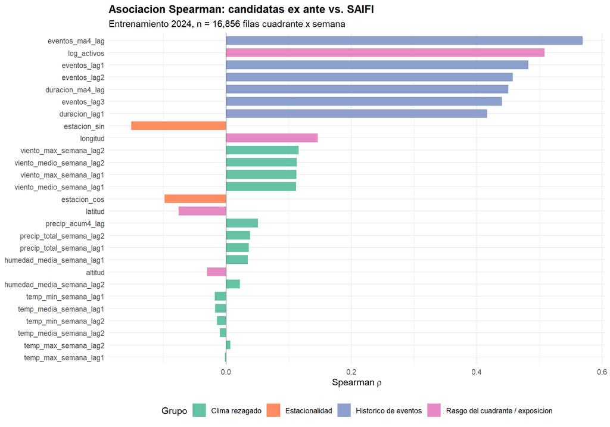

```r
df_plot_asoc <- asociacion %>%
  filter(!is.na(rho_saifi)) %>%
  mutate(variable = fct_reorder(variable, abs(rho_saifi)))

p_asoc <- ggplot(df_plot_asoc, aes(x = variable, y = rho_saifi, fill = grupo)) +
  geom_col(width = 0.72) +
  geom_hline(yintercept = 0, linewidth = 0.3) +
  coord_flip() +
  scale_fill_brewer(palette = "Set2", name = "Grupo") +
  labs(
    title = "Asociacion Spearman: candidatas ex ante vs. SAIFI",
    subtitle = paste0("Entrenamiento ", ANIO_TRAIN, ", n = ", format(nrow(d_train), big.mark = ","),
                      " filas cuadrante x semana"),
    x = NULL, y = expression(Spearman~rho)
  ) +
  theme_minimal(base_size = 11) +
  theme(plot.title = element_text(face = "bold"), legend.position = "bottom")

p_asoc
```

```r
guardar_plot(p_asoc, "asociacion_candidatas_exante_mod.png", 10, 7)
```

```
## [1] TRUE
```

```r
vars_sin_asociacion <- asociacion %>%
  filter(!signif_alguna | is.na(rho_saifi)) %>%
  pull(variable)

if (length(vars_sin_asociacion) == 0) {
  cat("Todas las candidatas presentan asociacion significativa (FDR 5%) con al menos una respuesta.\n")
} else {
  kable(
    asociacion %>%
      filter(variable %in% vars_sin_asociacion) %>%
      transmute(variable, grupo,
                rho_saifi = round(rho_saifi, 3),
                fdr_saifi = signif(fdr_saifi, 3),
                fdr_saidi = signif(fdr_saidi, 3)),
    col.names = c("Variable", "Grupo", "rho (SAIFI)", "FDR SAIFI", "FDR SAIDI"),
    caption = "Candidatas sin asociacion significativa con ninguna respuesta (FDR 5%)"
  )
}
```

Candidatas sin asociacion significativa con ninguna respuesta (FDR 5%)

| Variable | Grupo | rho (SAIFI) | FDR SAIFI | FDR SAIDI |
| --- | --- | --- | --- | --- |
| temp_media_semana_lag2 | Clima rezagado | -0.010 | 0.230 | 0.0587 |
| temp_max_semana_lag2 | Clima rezagado | 0.007 | 0.368 | 0.5990 |
| temp_max_semana_lag1 | Clima rezagado | -0.002 | 0.826 | 0.4720 |

## 4. Depuracion por redundancia

Se agrupan las candidatas con la distancia $d = 1-|\rho_{\text{Spearman}}|$ y enlace completo. Cada grupo con $|\rho| \geq 0.7$ se representa por la variable de mayor $|\rho|$ con `SAIFI`; las demas se marcan como redundantes.

```r
vars_para_redundancia <- setdiff(candidatas, c(vars_varianza_nula, vars_sin_asociacion))

mat_train <- as.matrix(d_train[, vars_para_redundancia])
rho_cand <- cor(mat_train, method = "spearman")

dist_cand <- as.dist(1 - abs(rho_cand))
hc_cand <- hclust(dist_cand, method = "complete")
grupos_red <- cutree(hc_cand, h = 1 - UMBRAL_RHO_REDUNDANTE)

prioridad <- asociacion %>%
  filter(variable %in% vars_para_redundancia) %>%
  transmute(variable, fuerza = abs(rho_saifi))

tabla_redundancia <- tibble(
  variable = names(grupos_red),
  grupo_redundancia = as.integer(grupos_red)
) %>%
  left_join(prioridad, by = "variable") %>%
  group_by(grupo_redundancia) %>%
  arrange(desc(fuerza), .by_group = TRUE) %>%
  mutate(
    representante = first(variable),
    conservada_redundancia = variable == representante,
    tamano_grupo = n()
  ) %>%
  ungroup()

kable(
  tabla_redundancia %>%
    filter(tamano_grupo > 1) %>%
    transmute(
      grupo_redundancia, variable,
      fuerza = round(fuerza, 3),
      representante,
      decision = if_else(conservada_redundancia, "Conservar", "Eliminar por redundancia")
    ) %>%
    arrange(grupo_redundancia, desc(fuerza)),
  col.names = c("Grupo", "Variable", "|rho| con SAIFI", "Representante", "Decision"),
  caption = paste0("Grupos redundantes (|rho| >= ", UMBRAL_RHO_REDUNDANTE, ")")
)
```

Grupos redundantes (|rho| >= 0.7)

| Grupo | Variable | \|rho\| con SAIFI | Representante | Decision |
| --- | --- | --- | --- | --- |
| 1 | altitud | 0.030 | altitud | Conservar |
| 1 | temp_min_semana_lag1 | 0.018 | altitud | Eliminar por redundancia |
| 1 | temp_media_semana_lag1 | 0.017 | altitud | Eliminar por redundancia |
| 1 | temp_min_semana_lag2 | 0.014 | altitud | Eliminar por redundancia |
| 2 | humedad_media_semana_lag1 | 0.035 | humedad_media_semana_lag1 | Conservar |
| 2 | humedad_media_semana_lag2 | 0.022 | humedad_media_semana_lag1 | Eliminar por redundancia |
| 3 | viento_max_semana_lag2 | 0.116 | viento_max_semana_lag2 | Conservar |
| 3 | viento_medio_semana_lag2 | 0.113 | viento_max_semana_lag2 | Eliminar por redundancia |
| 3 | viento_max_semana_lag1 | 0.112 | viento_max_semana_lag2 | Eliminar por redundancia |
| 3 | viento_medio_semana_lag1 | 0.112 | viento_max_semana_lag2 | Eliminar por redundancia |
| 3 | latitud | 0.076 | viento_max_semana_lag2 | Eliminar por redundancia |
| 7 | eventos_lag1 | 0.482 | eventos_lag1 | Conservar |
| 7 | duracion_lag1 | 0.416 | eventos_lag1 | Eliminar por redundancia |
| 10 | eventos_ma4_lag | 0.569 | eventos_ma4_lag | Conservar |
| 10 | duracion_ma4_lag | 0.451 | eventos_ma4_lag | Eliminar por redundancia |

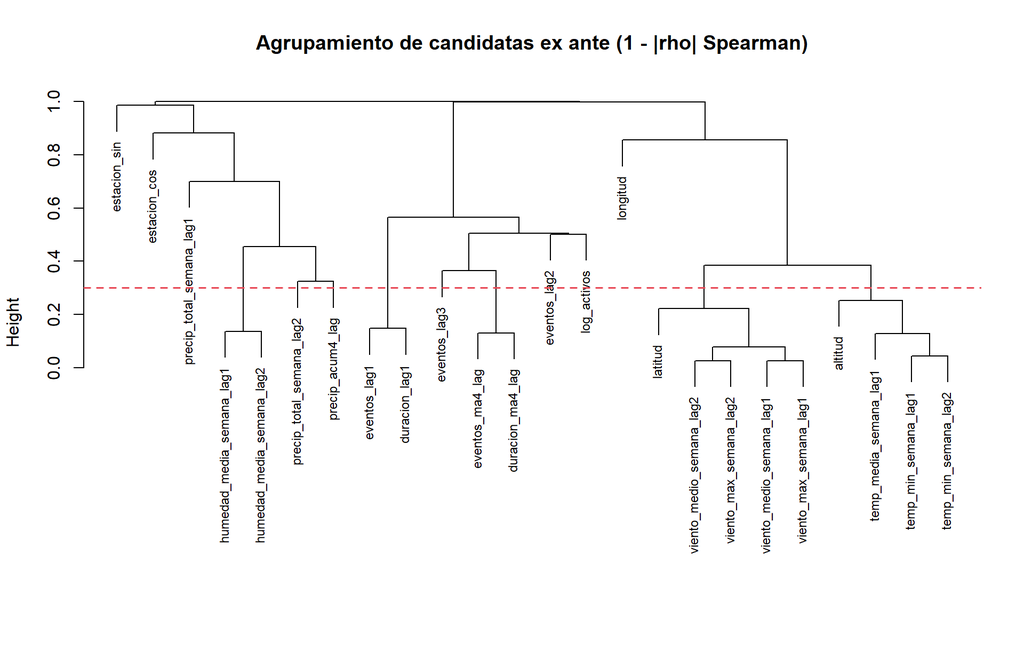

```r
png_dendro <- file.path(UBICACION_DATA, "dendrograma_candidatas_exante_mod.png")
plot_dendro <- function() {
  plot(hc_cand, main = "Agrupamiento de candidatas ex ante (1 - |rho| Spearman)",
       xlab = "", sub = "", cex = 0.75)
  abline(h = 1 - UMBRAL_RHO_REDUNDANTE, col = "#E84855", lty = 2, lwd = 1.5)
}

plot_dendro()
```

```r
png(png_dendro, width = 10, height = 6.5, units = "in", res = 300, bg = "white")
plot_dendro()
invisible(dev.off())

if (dir.exists(path_img_tesis)) {
  file.copy(png_dendro, file.path(path_img_tesis, basename(png_dendro)), overwrite = TRUE)
}
```

```
## [1] TRUE
```

## 5. Depuracion por multicolinealidad (VIF iterativo)

Sobre las representantes de cada grupo se calcula el VIF y se elimina de forma iterativa la variable con VIF mas alto hasta que todas queden por debajo de 5.

```r
vif_manual <- function(data, variables) {
  map_dfr(variables, function(v) {
    otras <- setdiff(variables, v)
    if (length(otras) == 0) {
      return(tibble(variable = v, vif = 1))
    }
    fmla <- as.formula(paste0("`", v, "` ~ ", paste0("`", otras, "`", collapse = " + ")))
    r2 <- summary(lm(fmla, data = data))$r.squared
    tibble(variable = v, vif = if (r2 >= 1) Inf else 1 / (1 - r2))
  }) %>%
    arrange(desc(vif))
}

vars_vif <- tabla_redundancia %>%
  filter(conservada_redundancia) %>%
  pull(variable)

vif_traza <- tibble()
eliminadas_vif <- character(0)

repeat {
  vif_actual <- vif_manual(d_train, vars_vif)
  peor <- vif_actual %>% slice_head(n = 1)

  vif_traza <- bind_rows(
    vif_traza,
    vif_actual %>% mutate(iteracion = length(eliminadas_vif) + 1)
  )

  if (!is.finite(peor$vif) || peor$vif < UMBRAL_VIF || length(vars_vif) <= 2) {
    break
  }

  eliminadas_vif <- c(eliminadas_vif, peor$variable)
  vars_vif <- setdiff(vars_vif, peor$variable)
}

vif_final <- vif_manual(d_train, vars_vif) %>%
  mutate(
    grupo = grupo_candidata(variable),
    vif = round(vif, 2),
    nivel = case_when(vif >= 10 ~ "Alta (>=10)", vif >= 5 ~ "Moderada (>=5)",
                      TRUE ~ "Baja (<5)")
  )

kable(vif_final %>% select(variable, grupo, vif, nivel),
      col.names = c("Variable", "Grupo", "VIF", "Nivel"),
      caption = "VIF del conjunto retenido tras la depuracion iterativa")
```

VIF del conjunto retenido tras la depuracion iterativa

| Variable | Grupo | VIF | Nivel |
| --- | --- | --- | --- |
| precip_acum4_lag | Clima rezagado | 4.02 | Baja (<5) |
| humedad_media_semana_lag1 | Clima rezagado | 3.55 | Baja (<5) |
| viento_max_semana_lag2 | Clima rezagado | 2.33 | Baja (<5) |
| eventos_lag2 | Historico de eventos | 2.11 | Baja (<5) |
| eventos_lag3 | Historico de eventos | 1.98 | Baja (<5) |
| eventos_lag1 | Historico de eventos | 1.98 | Baja (<5) |
| altitud | Rasgo del cuadrante / exposicion | 1.93 | Baja (<5) |
| precip_total_semana_lag2 | Clima rezagado | 1.84 | Baja (<5) |
| precip_total_semana_lag1 | Clima rezagado | 1.72 | Baja (<5) |
| longitud | Rasgo del cuadrante / exposicion | 1.50 | Baja (<5) |
| estacion_cos | Estacionalidad | 1.47 | Baja (<5) |
| log_activos | Rasgo del cuadrante / exposicion | 1.34 | Baja (<5) |
| estacion_sin | Estacionalidad | 1.32 | Baja (<5) |

```r
if (length(eliminadas_vif) == 0) {
  cat("Ninguna variable requirio eliminacion por VIF.\n")
} else {
  kable(
    vif_traza %>%
      filter(variable %in% eliminadas_vif) %>%
      group_by(variable) %>%
      slice_min(iteracion, with_ties = FALSE) %>%
      ungroup() %>%
      transmute(iteracion, variable, vif = round(vif, 2)) %>%
      arrange(iteracion),
    col.names = c("Iteracion", "Variable eliminada", "VIF al eliminarse"),
    caption = "Traza de eliminacion por multicolinealidad"
  )
}
```

Traza de eliminacion por multicolinealidad

| Iteracion | Variable eliminada | VIF al eliminarse |
| --- | --- | --- |
| 1 | eventos_ma4_lag | 24.03 |

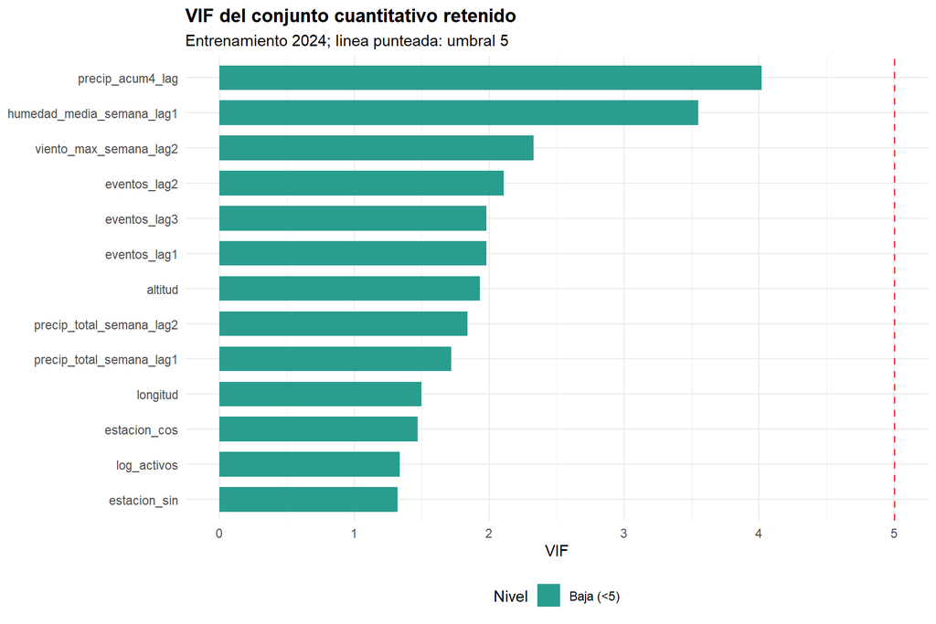

```r
p_vif <- ggplot(vif_final, aes(x = fct_reorder(variable, vif), y = vif, fill = nivel)) +
  geom_col(width = 0.7) +
  geom_hline(yintercept = UMBRAL_VIF, linetype = "dashed", color = "#E84855", linewidth = 0.7) +
  coord_flip() +
  scale_fill_manual(values = c("Baja (<5)" = "#2A9D8F", "Moderada (>=5)" = "#F4A261",
                               "Alta (>=10)" = "#E84855"), name = "Nivel") +
  labs(
    title = "VIF del conjunto cuantitativo retenido",
    subtitle = paste0("Entrenamiento ", ANIO_TRAIN, "; linea punteada: umbral ", UMBRAL_VIF),
    x = NULL, y = "VIF"
  ) +
  theme_minimal(base_size = 11) +
  theme(plot.title = element_text(face = "bold"), legend.position = "bottom")

p_vif
```

```r
guardar_plot(p_vif, "vif_cuanti_depurado_mod.png", 9, 6)
```

```
## [1] TRUE
```

## 6. Bitacora de decisiones

```r
bitacora <- asociacion %>%
  select(variable, grupo, rho_saifi, fdr_saifi, rho_saidi, fdr_saidi) %>%
  left_join(
    tabla_redundancia %>% select(variable, grupo_redundancia, representante, tamano_grupo),
    by = "variable"
  ) %>%
  left_join(vif_final %>% select(variable, vif), by = "variable") %>%
  mutate(
    decision = case_when(
      variable %in% vars_varianza_nula ~ "Eliminar",
      variable %in% vars_sin_asociacion ~ "Eliminar",
      variable %in% eliminadas_vif ~ "Eliminar",
      !is.na(representante) & variable != representante ~ "Eliminar",
      variable %in% vars_vif ~ "Conservar",
      TRUE ~ "Eliminar"
    ),
    motivo = case_when(
      variable %in% vars_varianza_nula ~ "Varianza casi nula en entrenamiento",
      variable %in% vars_sin_asociacion ~
        paste0("Sin asociacion significativa con las respuestas (FDR ",
               UMBRAL_ALPHA_FDR * 100, "%)"),
      variable %in% eliminadas_vif ~ paste0("Multicolinealidad (VIF >= ", UMBRAL_VIF, ")"),
      !is.na(representante) & variable != representante ~
        paste0("Redundante con ", representante, " (|rho| >= ", UMBRAL_RHO_REDUNDANTE, ")"),
      variable %in% vars_vif ~ "Aporta señal ex ante, sin redundancia ni VIF alto",
      TRUE ~ "No retenida"
    )
  ) %>%
  arrange(decision, grupo, desc(abs(rho_saifi)))

bitacora_export <- bitacora %>%
  transmute(
    variable, grupo, decision, motivo,
    rho_SAIFI = round(rho_saifi, 4),
    fdr_SAIFI = signif(fdr_saifi, 4),
    rho_SAIDI = round(rho_saidi, 4),
    fdr_SAIDI = signif(fdr_saidi, 4),
    vif_final = round(vif, 3),
    grupo_redundancia, representante_redundancia = representante
  ) %>%
  bind_rows(
    excluidas_diseno %>%
      transmute(
        variable, grupo = "Excluida por diseño",
        decision = "Eliminar", motivo
      )
  ) %>%
  bind_rows(
    cobertura %>%
      filter(variable %in% vars_cobertura_baja) %>%
      transmute(
        variable, grupo,
        decision = "Eliminar",
        motivo = paste0("Cobertura insuficiente (", cobertura, "%)")
      )
  )

kable(
  bitacora %>%
    transmute(variable, grupo, decision, motivo,
              rho_saifi = round(rho_saifi, 3),
              vif = round(vif, 2)),
  col.names = c("Variable", "Grupo", "Decision", "Motivo", "rho (SAIFI)", "VIF"),
  caption = "Bitacora de depuracion cuantitativa"
)
```

Bitacora de depuracion cuantitativa

| Variable | Grupo | Decision | Motivo | rho (SAIFI) | VIF |
| --- | --- | --- | --- | --- | --- |
| viento_max_semana_lag2 | Clima rezagado | Conservar | Aporta señal ex ante, sin redundancia ni VIF alto | 0.116 | 2.33 |
| precip_acum4_lag | Clima rezagado | Conservar | Aporta señal ex ante, sin redundancia ni VIF alto | 0.051 | 4.02 |
| precip_total_semana_lag2 | Clima rezagado | Conservar | Aporta señal ex ante, sin redundancia ni VIF alto | 0.038 | 1.84 |
| precip_total_semana_lag1 | Clima rezagado | Conservar | Aporta señal ex ante, sin redundancia ni VIF alto | 0.036 | 1.72 |
| humedad_media_semana_lag1 | Clima rezagado | Conservar | Aporta señal ex ante, sin redundancia ni VIF alto | 0.035 | 3.55 |
| estacion_sin | Estacionalidad | Conservar | Aporta señal ex ante, sin redundancia ni VIF alto | -0.151 | 1.32 |
| estacion_cos | Estacionalidad | Conservar | Aporta señal ex ante, sin redundancia ni VIF alto | -0.098 | 1.47 |
| eventos_lag1 | Historico de eventos | Conservar | Aporta señal ex ante, sin redundancia ni VIF alto | 0.482 | 1.98 |
| eventos_lag2 | Historico de eventos | Conservar | Aporta señal ex ante, sin redundancia ni VIF alto | 0.457 | 2.11 |
| eventos_lag3 | Historico de eventos | Conservar | Aporta señal ex ante, sin redundancia ni VIF alto | 0.440 | 1.98 |
| log_activos | Rasgo del cuadrante / exposicion | Conservar | Aporta señal ex ante, sin redundancia ni VIF alto | 0.508 | 1.34 |
| longitud | Rasgo del cuadrante / exposicion | Conservar | Aporta señal ex ante, sin redundancia ni VIF alto | 0.146 | 1.50 |
| altitud | Rasgo del cuadrante / exposicion | Conservar | Aporta señal ex ante, sin redundancia ni VIF alto | -0.030 | 1.93 |
| viento_medio_semana_lag2 | Clima rezagado | Eliminar | Redundante con viento_max_semana_lag2 (\|rho\| >= 0.7) | 0.113 | NA |
| viento_max_semana_lag1 | Clima rezagado | Eliminar | Redundante con viento_max_semana_lag2 (\|rho\| >= 0.7) | 0.112 | NA |
| viento_medio_semana_lag1 | Clima rezagado | Eliminar | Redundante con viento_max_semana_lag2 (\|rho\| >= 0.7) | 0.112 | NA |
| humedad_media_semana_lag2 | Clima rezagado | Eliminar | Redundante con humedad_media_semana_lag1 (\|rho\| >= 0.7) | 0.022 | NA |
| temp_min_semana_lag1 | Clima rezagado | Eliminar | Redundante con altitud (\|rho\| >= 0.7) | -0.018 | NA |
| temp_media_semana_lag1 | Clima rezagado | Eliminar | Redundante con altitud (\|rho\| >= 0.7) | -0.017 | NA |
| temp_min_semana_lag2 | Clima rezagado | Eliminar | Redundante con altitud (\|rho\| >= 0.7) | -0.014 | NA |
| temp_media_semana_lag2 | Clima rezagado | Eliminar | Sin asociacion significativa con las respuestas (FDR 5%) | -0.010 | NA |
| temp_max_semana_lag2 | Clima rezagado | Eliminar | Sin asociacion significativa con las respuestas (FDR 5%) | 0.007 | NA |
| temp_max_semana_lag1 | Clima rezagado | Eliminar | Sin asociacion significativa con las respuestas (FDR 5%) | -0.002 | NA |
| eventos_ma4_lag | Historico de eventos | Eliminar | Multicolinealidad (VIF >= 5) | 0.569 | NA |
| duracion_ma4_lag | Historico de eventos | Eliminar | Redundante con eventos_ma4_lag (\|rho\| >= 0.7) | 0.451 | NA |
| duracion_lag1 | Historico de eventos | Eliminar | Redundante con eventos_lag1 (\|rho\| >= 0.7) | 0.416 | NA |
| latitud | Rasgo del cuadrante / exposicion | Eliminar | Redundante con viento_max_semana_lag2 (\|rho\| >= 0.7) | -0.076 | NA |

```r
kable(
  bitacora %>% count(decision, grupo, name = "n"),
  col.names = c("Decision", "Grupo", "Variables"),
  caption = "Resumen de decisiones por grupo"
)
```

Resumen de decisiones por grupo

| Decision | Grupo | Variables |
| --- | --- | --- |
| Conservar | Clima rezagado | 5 |
| Conservar | Estacionalidad | 2 |
| Conservar | Historico de eventos | 3 |
| Conservar | Rasgo del cuadrante / exposicion | 3 |
| Eliminar | Clima rezagado | 10 |
| Eliminar | Historico de eventos | 3 |
| Eliminar | Rasgo del cuadrante / exposicion | 1 |

## 7. Matriz de diseño depurada

Se exporta la matriz de diseño con las llaves (`id_cuadrante`, `semana`), la marca de particion temporal, las respuestas `SAIFI` y `SAIDI`, el divisor `usuarios_totales`, el *offset* de exposicion y las predictoras cuantitativas retenidas. `n_eventos` y `duracion_total` se conservan como insumos de construccion e historico, no como variables a predecir. Las metricas de impacto posterior no entran como predictoras: permanecen en `data_agrupada_mod.csv`.

```r
vars_retenidas <- bitacora %>% filter(decision == "Conservar") %>% pull(variable)

vars_offset <- intersect("log_activos", vars_retenidas)

d_diseno <- d_completo %>%
  select(
    id_cuadrante, semana, anio, particion,
    SAIFI, SAIDI, usuarios_totales,
    n_eventos, duracion_total,
    any_of(vars_offset),
    all_of(setdiff(vars_retenidas, vars_offset))
  )

write_csv(d_diseno, path_salida_datos)
write_csv(bitacora_export, path_salida_bitacora)

kable(
  tibble(
    archivo = c(basename(path_salida_datos), basename(path_salida_bitacora)),
    filas = format(c(nrow(d_diseno), nrow(bitacora_export)), big.mark = ","),
    columnas = c(ncol(d_diseno), ncol(bitacora_export))
  ),
  col.names = c("Archivo exportado", "Filas", "Columnas"),
  caption = "Salidas del proceso de depuracion cuantitativa"
)
```

Salidas del proceso de depuracion cuantitativa

| Archivo exportado | Filas | Columnas |
| --- | --- | --- |
| data_modelado_cuanti.csv | 34,744 | 22 |
| decision_variables_cuanti.csv | 40 | 11 |

```r
kable(
  d_diseno %>%
    count(particion, anio, name = "filas") %>%
    mutate(filas = format(filas, big.mark = ",")),
  col.names = c("Particion", "Año", "Filas"),
  caption = "Particion temporal de la matriz de diseño"
)
```

Particion temporal de la matriz de diseño

| Particion | Año | Filas |
| --- | --- | --- |
| entrenamiento | 2024 | 16,856 |
| prueba | 2025 | 17,888 |

```r
kable(
  tibble(columna = names(d_diseno), tipo = map_chr(d_diseno, ~ class(.x)[1])),
  col.names = c("Columna", "Tipo"),
  caption = "Estructura de data_modelado_cuanti.csv"
)
```

Estructura de data_modelado_cuanti.csv

| Columna | Tipo |
| --- | --- |
| id_cuadrante | character |
| semana | Date |
| anio | numeric |
| particion | character |
| SAIFI | numeric |
| SAIDI | numeric |
| usuarios_totales | numeric |
| n_eventos | numeric |
| duracion_total | numeric |
| log_activos | numeric |
| viento_max_semana_lag2 | numeric |
| precip_acum4_lag | numeric |
| precip_total_semana_lag2 | numeric |
| precip_total_semana_lag1 | numeric |
| humedad_media_semana_lag1 | numeric |
| estacion_sin | numeric |
| estacion_cos | numeric |
| eventos_lag1 | numeric |
| eventos_lag2 | numeric |
| eventos_lag3 | numeric |
| longitud | numeric |
| altitud | numeric |

```r
head(d_diseno)
```

```
## # A tibble: 6 × 22
##   id_cuadrante semana      anio particion SAIFI SAIDI usuarios_totales n_eventos
##   <chr>        <date>     <dbl> <chr>     <dbl> <dbl>            <dbl>     <dbl>
## 1 1            2024-01-29  2024 entrenam…     0     0           618400         0
## 2 1            2024-02-05  2024 entrenam…     0     0           619881         0
## 3 1            2024-02-12  2024 entrenam…     0     0           619881         0
## 4 1            2024-02-19  2024 entrenam…     0     0           619881         0
## 5 1            2024-02-26  2024 entrenam…     0     0           619881         0
## 6 1            2024-03-04  2024 entrenam…     0     0           621283         0
## # ℹ 14 more variables: duracion_total <dbl>, log_activos <dbl>,
## #   viento_max_semana_lag2 <dbl>, precip_acum4_lag <dbl>,
## #   precip_total_semana_lag2 <dbl>, precip_total_semana_lag1 <dbl>,
## #   humedad_media_semana_lag1 <dbl>, estacion_sin <dbl>, estacion_cos <dbl>,
## #   eventos_lag1 <dbl>, eventos_lag2 <dbl>, eventos_lag3 <dbl>, longitud <dbl>,
## #   altitud <dbl>
```

## 8. Sintesis

```r
mejor_clima <- asociacion %>%
  filter(grupo == "Clima rezagado", !is.na(rho_saifi)) %>%
  slice_max(abs(rho_saifi), n = 1, with_ties = FALSE)

mejor_historico <- asociacion %>%
  filter(grupo == "Historico de eventos", !is.na(rho_saifi)) %>%
  slice_max(abs(rho_saifi), n = 1, with_ties = FALSE)

sintesis <- tibble(
  aspecto = c(
    "Candidatas ex ante evaluadas",
    "Retenidas para la matriz de diseño",
    "Eliminadas por redundancia",
    "Eliminadas por VIF",
    "Eliminadas por asociacion no significativa",
    "Mayor senal climatica rezagada",
    "Mayor senal del historico",
    "Filas utilizables tras rezagos"
  ),
  valor = c(
    as.character(length(candidatas)),
    as.character(length(vars_retenidas)),
    as.character(sum(bitacora$decision == "Eliminar" &
                       grepl("^Redundante", bitacora$motivo))),
    as.character(length(eliminadas_vif)),
    as.character(length(vars_sin_asociacion)),
    paste0(mejor_clima$variable, " (rho = ", round(mejor_clima$rho_saifi, 3), ")"),
    paste0(mejor_historico$variable, " (rho = ", round(mejor_historico$rho_saifi, 3), ")"),
    paste0(format(nrow(d_completo), big.mark = ","), " de ",
           format(nrow(d_feat), big.mark = ","))
  )
)

kable(sintesis, col.names = c("Aspecto", "Valor"),
      caption = "Sintesis de la depuracion cuantitativa")
```

Sintesis de la depuracion cuantitativa

| Aspecto | Valor |
| --- | --- |
| Candidatas ex ante evaluadas | 27 |
| Retenidas para la matriz de diseño | 13 |
| Eliminadas por redundancia | 10 |
| Eliminadas por VIF | 1 |
| Eliminadas por asociacion no significativa | 3 |
| Mayor senal climatica rezagada | viento_max_semana_lag2 (rho = 0.116) |
| Mayor senal del historico | eventos_ma4_lag (rho = 0.569) |
| Filas utilizables tras rezagos | 34,744 de 36,120 |

El conjunto retenido constituye el bloque cuantitativo de la matriz de diseño de la Etapa 4. La depuracion respeta la taxonomia de tres grupos: solo entran variables disponibles antes de la semana pronosticada; `SAIFI` y `SAIDI` son las respuestas; y las metricas de impacto posterior quedan fuera de la matriz de diseño como predictoras, sin ser eliminadas del panel.

Pendiente en la misma etapa: depuracion de variables **cualitativas** (codificacion de factores *ex ante* y agrupamiento de niveles), estandarizacion de las continuas retenidas y validacion cruzada de origen movil dentro de 2024.